# Week 4 Assignment

Rishav Chaudhary

Presidential Graduate School, Kathmandu, Nepal

PRG 330: Python Programming for Data

Professor Tek Raj Panta

November 17, 2024

# Basics of Machine Learning

## Exploration of Iris dataset

```
   sepal length (cm)  sepal width (cm)  petal length (cm)  petal width (cm)  \
0                5.1               3.5                1.4               0.2
1                4.9               3.0                1.4               0.2
2                4.7               3.2                1.3               0.2
3                4.6               3.1                1.5               0.2
4                5.0               3.6                1.4               0.2

   species
0        0
1        0
2        0
3        0
4        0
```

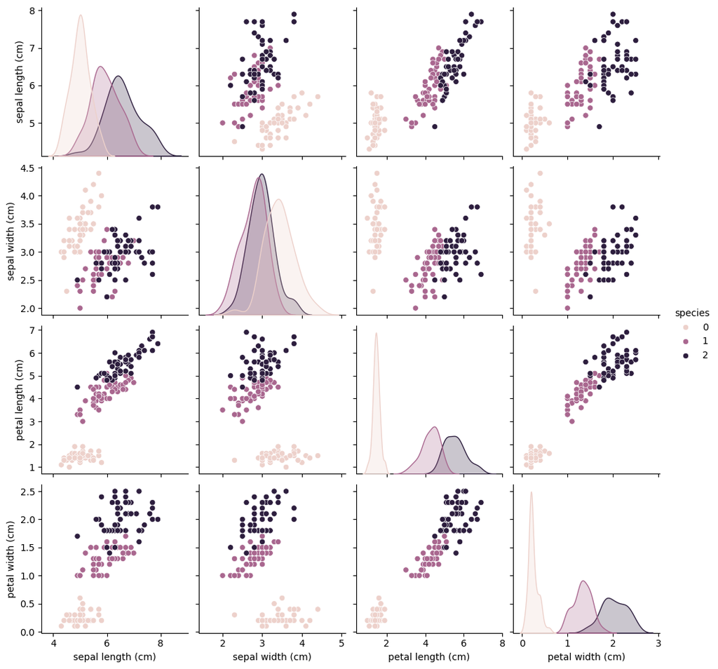

```python
import pandas as pd
import matplotlib.pyplot as plt
import seaborn as sns
# Importing iris data set from sklearn for machine learning
from sklearn.datasets import load_iris
# Importing train_test_split from model_selection from sklearn
from sklearn.model_selection import train_test_split
# Importing logistic regression function from linear model
from sklearn.linear_model import LogisticRegression
# Importing accuracy_score for accuracy measurement, classification_report, and confusion_matrix
from sklearn.metrics import accuracy_score, classification_report, confusion_matrix

# Loading Iris Dataset from scikit-learn
iris = load_iris()

iris_dataframe = pd.DataFrame(iris.data, columns=iris.feature_names)
iris_dataframe["species"] = iris.target

# printing first few rows of the dataset
print(iris_dataframe.head())

# visualizing the dataset
sns.pairplot(iris_dataframe, hue="species", diag_kind="kde")
plt.show()
```

### Explanation

For learning basics regarding machine learning and scikit learn module in Python, we need to load a Dataset. Iris Dataset comes preloaded from sci-kit learn library. It is the beginner friendly dataset to learn sci-kit module. From sklearn.datasets, we imported load_iris function to load the dataset to iris variable. For splitting data into training and testing data from iris data, train_test_split function is imported from sklearn.model_selection. Logistic Regression model is imported from sklearn.linear_model as Logistic Regression is simple model to start with. For measuring our predictive score with known data, accuracy_score, classification_report and confusion_matrix is imported from sklearn.metrics.

Iris data was loaded, made into dataframe. iris.data has the data in list form, while iris.feature_names has columns. It was used for making into dataframe. species column was added and iris.target data was used. The exploration of dataset ended with printing the first few rows.

The columns has sepal length, sepal width, petal length, petal width and species. Then, again the exploration could not be ended here so a pairplot was made to understand the relation of each column with respect to others to species.

## Splitting data into features (X) and target(y)

Here, features are columns that we are dependend upon to see the relation to the output which will be the target variable or columns. Here, we will choose Sepal and petal measurements as features to depend upon to see which target species it provides.

we need training data to train the model and testing data to test the result. so, train_test_split function is used to split the data here. We are using supervised machine learning here.

```python
x = iris_dataframe[iris.feature_names] # features which is sepal and petal measurements
y = iris_dataframe["species"] # Target which is species, the relation of sepal and petal to know which species

# Splitting dataset to training and testing sets (80-train to 20-test)
x_train, x_test, y_train, y_test = train_test_split(x, y, test_size=0.2, random_state=42)
```

## Training the model using Logistic Regression

```
Model Accuracy: 1.00
Classification Report:
              precision    recall  f1-score   support

           0       1.00      1.00      1.00        10
           1       1.00      1.00      1.00         9
           2       1.00      1.00      1.00        11

    accuracy                           1.00        30
   macro avg       1.00      1.00      1.00        30
weighted avg       1.00      1.00      1.00        30
```

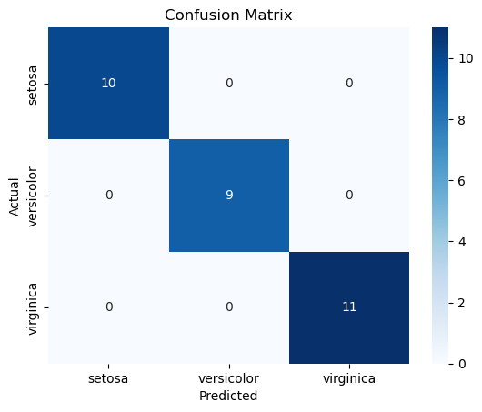

```python
# Train the model
# Using Logistic Regression (a simple supervised learning algorithm)
model = LogisticRegression(max_iter=200)
model.fit(x_train, y_train)

# Make predictions
y_pred = model.predict(x_test)

# Evaluate the model
# Accuracy Score
accuracy = accuracy_score(y_test, y_pred)
print(f"Model Accuracy: {accuracy:.2f}")

# Classification Report
print("Classification Report:")
print(classification_report(y_test, y_pred))

# Confusion Matrix
cm = confusion_matrix(y_test, y_pred)
sns.heatmap(cm, annot=True, cmap='Blues', fmt='d', xticklabels=iris.target_names, yticklabels=iris.target_names)
plt.title("Confusion Matrix")
plt.xlabel("Predicted")
plt.ylabel("Actual")
plt.show()
```

### Explanation

We train the model using Logistic Regression which is simple yet effective supervised learning algorithm for classification based on species. The maximum iteration limit is initialized to ensure the model converges during training. We used .fit() method to train the model using training dataset we splitted earlier which learned patterns and relationship between input features (sepal and petal measurements) and the target labels which is flower species.

The trained model is used to make predictions using test data using the .predict() method. The predictions (y_pred) represented the species classification for the test samples based on the model understanding.

Finally, we evaluated the model;s performance using accuracy score which amounted to 1. This measures the proportion of correct predicions to the total number of test samples. The classification_report() provided the detailed report of model's precision, recall, fi-score and support for each species. This helps us understand how well the model performs for each category. Finally, the confusion matris is computed using confusion_matrix() and visualized it using the seaborn.